# Lecture 4: Model Selection

### Model calibration

- For some models, the *predicted* uncertainty does not reflect the *actual* uncertainty
  - If a model is 90% sure that samples are positive, is it also 90% accurate on these?
- A model is called *calibrated* if the reported uncertainty actually matches how correct it is
  - Overfitted models also tend to be over-confident
  - LogisticRegression models are well calibrated since they learn probabilities
  - SVMs are not well calibrated. *Biased* towards points close to the decision boundary.

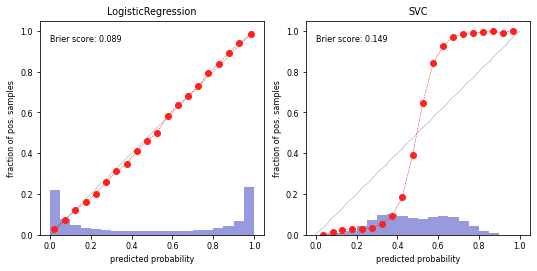

#### Brier score

- You may want to select models based on how accurate the class confidences are.
- The **Brier score loss**: squared loss between predicted probability $\hat{p}$ and actual outcome $y$
  - Lower is better $$\mathcal{L}_{Brier} = \frac{1}{n}\sum_{i=1}^n (\hat{p}_i - y_i)^2$$

```
Logistic Regression Brier score loss: 0.0322
SVM Brier score loss: 0.0795
```

#### Model calibration techniques

- We can post-process trained models to make them more calibrated.
- Fit a regression model (a calibrator) to map the model's outcomes $f(x)$ to a calibrated probability in [0,1]
  - $f(x)$ returns the decision values or probability estimates
  - $f_{calib}$ is fitted on the training data to map these to the correct outcome
    - Often an internal cross-validation with few folds is used
  - Multi-class models require one calibrator per class

$$f_{calib}(f(x))≈p(y)$$

##### Platt Scaling

- Calibrator is a logistic (sigmoid) function:
  - Learn the weight $w_1$ and bias $w_0$ from data $$f_{platt}=\frac{1}{1+\exp(−w_1 f(x)− w_0)}$$

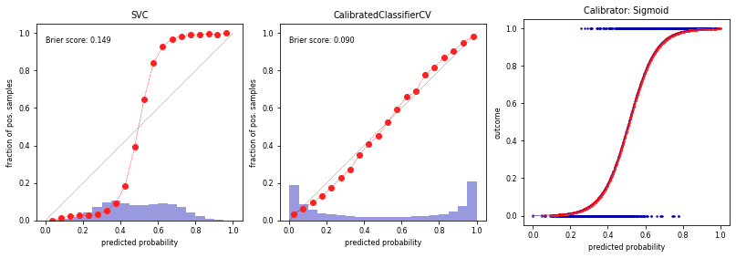

##### Isotonic regression

- Maps input $x_i$ to an output $\hat{y}_i$ so that $\hat{y}_i$ increases monotonically with $x_i$ and minimizes loss $\sum_i^n (y_i-\hat{y}_i)$
  - Predictions are made by interpolating the predicted $\hat{y}_i$
- Fit to minimize the loss between the uncalibrated predictions $f(x)$ and the actual labels
- Corrects any monotonic distortion, but tends to overfit on small samples

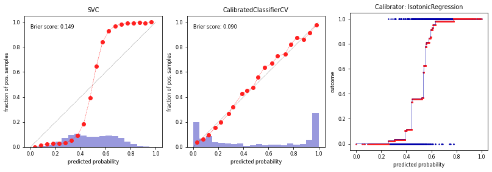

## Cost-sensitive classification (dealing with imbalance)

- In the real worlds, different kinds of misclassification can have different costs
  - Misclassifying certain classes can be more costly than others
  - Misclassifying certain samples can be more costly than others
- Cost-sensitive resampling: resample (or reweight) the data to represent real-world expectations
  - oversample minority classes (or undersample majority) to 'correct' imbalance
  - increase weight of misclassified samples (e.g. in boosting)
  - decrease weight of misclassified (noisy) samples (e.g. in model compression)

### Class weighting

- If some classes are more important than others, we can give them more weight
  - E.g. for imbalanced data, we can give more weight to minority classes
- Most classification models can include it in their loss function and optimize for it
  - E.g. Logistic regression: add a class weight $w_c$ in the log loss function $$\mathcal{L_{log}}(\mathbf{w}) = - \sum_{c=1}^{C} \color{red}{w_c} \sum_{n=1}^{N} p_{n,c} log(q_{n,c}) $$

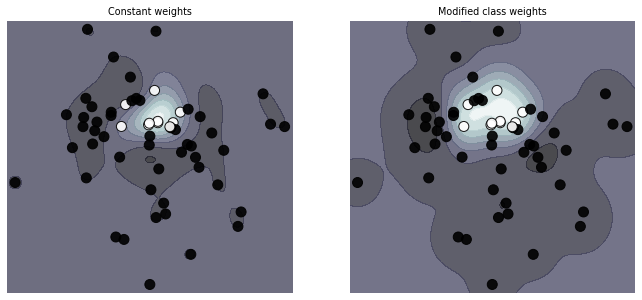

### Instance weighting

- If some *training instances* are important to get right, we can give them more weight
  - E.g. when some examples are from groups underrepresented in the data
- These are passed during training (fit), and included in the loss function
  - E.g. Logistic regression: add a instance weight $w_n$ in the log loss function $$\mathcal{L_{log}}(\mathbf{w}) = - \sum_{c=1}^{C} \sum_{n=1}^{N} \color{red}{w_n} p_{n,c} log(q_{n,c}) $$

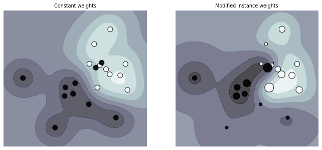

### Cost-sensitive algorithms

- Cost-sensitive algorithms
  - If misclassification cost of some classes is higher, we can give them higher weights
  - Some support *cost matrix* $C$: costs $c_{i,j}$ for every possible type of error
- Cost-sensitive ensembles: convert cost-insensitive classifiers into cost-sensitive ones
  - MetaCost: Build a model (ensemble) to learn the class probabilities $P(j|x)$
    - Relabel training data to minimize expected cost: $\underset{i}{\operatorname{argmin}} \sum_j P_j(x) c_{i,j}$
    - Accuracy may decrease but cost decreases as well.
  - AdaCost: Boosting with reweighting instances to reduce costs

### Tuning the decision threshold

- If every FP or FN has a certain cost, we can compute the total cost for a given model: $$\text{total cost} = \text{FPR} * cost_{FP} * ratio_{pos} + (1-\text{TPR}) * cost_{FN} * (1-ratio_{pos})$$
- This yields different *isometrics* (lines of equal cost) in ROC space
- Optimal threshold is the point on the ROC curve where cost is minimal (line search)

```
interactive(children=(FloatSlider(value=5.0, description='cost_FN', max=10.0, min=1.0, step=1.0), FloatSlider(…
```

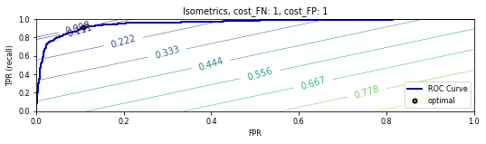

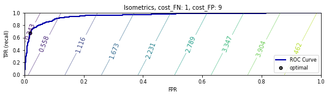

## Regression metrics

Most commonly used are

- mean squared error: $\frac{\sum_{i}(y_{pred_i}-y_{actual_i})^2}{n}$
  - root mean squared error (RMSE) often used as well
- mean absolute error: $\frac{\sum_{i}|y_{pred_i}-y_{actual_i}|}{n}$
  - Less sensitive to outliers and large errors

[figure not shown]

### R squared

- $R^2 = 1 - \frac{\color{blue}{\sum_{i}(y_{pred_i}-y_{actual_i})^2}}{\color{red}{\sum_{i}(y_{mean}-y_{actual_i})^2}}$
  - Ratio of variation explained by the model / total variation
  - Between 0 and 1, but *negative* if the model is worse than just predicting the mean
  - Easier to interpret (higher is better).

[figure not shown]

### Visualizing regression errors

- Prediction plot (left): predicted vs actual target values
- Residual plot (right): residuals vs actual target values
  - Over- and underpredictions can be given different costs

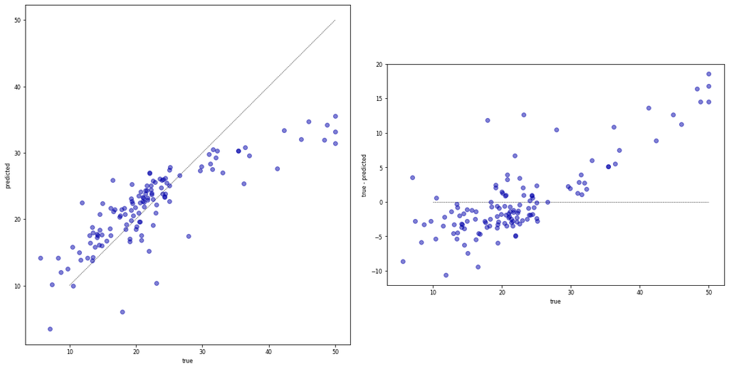

## Bias-Variance decomposition

- Evaluate the same algorithm multiple times on different random samples of the data
- Two types of errors can be observed:
  - Bias error: systematic error, independent of the training sample
    - These points are predicted (equally) wrong every time
  - Variance error: error due to variability of the model w.r.t. the training sample
    - These points are sometimes predicted accurately, sometimes inaccurately

[figure not shown]

### Computing bias and variance error

- Take 100 or more bootstraps (or shuffle-splits)
- Regression: for each data point x:
  - $bias(x)^2 = (x_{true} - mean(x_{predicted}))^2$
  - $variance(x) = var(x_{predicted})$
- Classification: for each data point x:
  - $bias(x)$ = misclassification ratio
  - $variance(x) = (1 - (P(class_1)^2 + P(class_2)^2))/2$
    - $P(class_i)$ is ratio of class $i$ predictions
- Total bias: $\sum_{x} bias(x)^2 * w_x$ $w_x$: the percentage of times $x$ occurs in the test sets
- Total variance: $\sum_{x} variance(x) * w_x$

### Bias and variance, underfitting and overfitting

- High variance means that you are likely overfitting
  - Use more regularization or use a simpler model
- High bias means that you are likely underfitting
  - Do less regularization or use a more flexible/complex model
- Ensembling techniques (see later) reduce bias or variance directly
  - Bagging (e.g. RandomForests) reduces variance, Boosting reduces bias

[figure not shown]

### Understanding under- and overfitting

- Regularization reduces variance error (increases stability of predictions)
  - But too much increases bias error (inability to learn 'harder' points)
- High regularization (left side): Underfitting, high bias error, low variance error
  - High training error and high test error
- Low regularization (right side): Overfitting, low bias error, high variance error
  - Low training error and higher test error

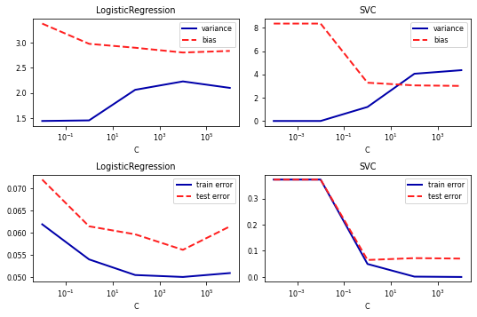

Summary Flowchart (by Andrew Ng)

[figure not shown]

## Hyperparameter tuning

- There exists a huge range of techniques to tune hyperparameters. The simplest:
  - Grid search: Choose a range of values for every hyperparameter, try every combination
    - Doesn't scale to many hyperparameters (combinatorial explosion)
  - Random search: Choose random values for all hyperparameters, iterate $n$ times
    - Better, especially when some hyperparameters are less important
- Many more advanced techniques exist, see lecture on Automated Machine Learning

[figure not shown]

- First, split the data in training and test sets (outer split)
- Split up the training data again (inner cross-validation)
  - Generate hyperparameter configurations (e.g. random/grid search)
  - Evaluate all configurations on all inner splits, select the best one (on average)
- Retrain best configurations on full training set, evaluate on held-out test data

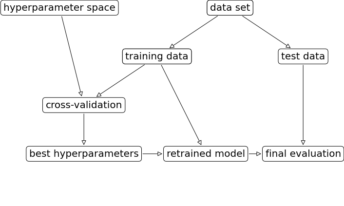

### Nested cross-validation

- Simplest approach: single outer split and single inner split (shown below)
- Risk of over-tuning hyperparameters on specific train-test split
  - Only recommended for very large datasets
- Nested cross-validation:
  - Outer loop: split full dataset in $k_1$ training and test splits
  - Inner loop: split training data into $k_2$ train and validation sets
- This yields $k_1$ scores for $k_1$ possibly different hyperparameter settings
  - Average score is the expected performance of the tuned model
- To use the model in practice, retune on the **entire** dataset

```
hps = {'C': expon(scale=100), 'gamma': expon(scale=.1)}
scores = cross_val_score(RandomizedSearchCV(SVC(), hps, cv=3), X, y, cv=5)
```

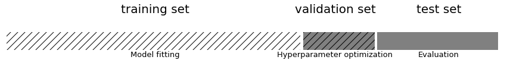

## Summary

- Split the data into training and test sets according to the application
  - Holdout only for large datasets, cross-validation for smaller ones
  - For classification, always use stratification
  - Grouped or ordered data requires special splitting
- Choose a metric that fits your application
  - E.g. precision to avoid false positives, recall to avoid false negatives
- Calibrate the decision threshold to fit your application
  - ROC curves or Precision-Recall curves can help to find a good tradeoff
- If possible, include the actual or relative costs of misclassifications
  - Class weighting, instance weighting, ROC isometrics can help
  - Be careful with imbalanced or unrepresentative datasets
- When using the predicted probabilities in applications, calibrate the models
- Always tune the most important hyperparameters
  - Manual tuning: Use insight and train-test scores for guidance
  - Hyperparameter optimization: be careful not to over-tune